# Improvise a Jazz Solo with an LSTM Network

- Apply an LSTM to music generation.
- Generate your own jazz music with deep learning.

```python
from __future__ import print_function
import IPython
from IPython.display import Image
import sys
from music21 import *
import numpy as np
from grammar import *
from qa import *
from preprocess import *
from music_utils import *
from data_utils import *
from keras.models import load_model, Model
from keras.layers import Dense, Activation, Dropout, Input, LSTM, Reshape, Lambda, RepeatVector
from keras.initializers import glorot_uniform
from keras.utils import to_categorical
from keras.optimizers import Adam
from keras import backend as K
```

## Problem statement

You will train a LSTM network to generate novel jazz solos in a style representative of a body of performed work.

### Dataset

You will train your algorithm on a corpus of Jazz music. Run the cell below to listen to a snippet of the audio from the training set:

```python
IPython.display.Audio('./data/30s_seq.mp3')
```

[interactive chart not shown]

#### Details about music

You can informally think of each "value" as a note, which comprises a pitch and duration. For example, if you press down a specific piano key for 0.5 seconds, then you have just played a note. In music theory, a "value" is actually more complicated than this - specifically, it also captures the information needed to play multiple notes at the same time. For example, when playing a music piece, you might press down two piano keys at the same time (playing multiple notes at the same time generates what's called a "chord").

#### Music as a sequence of values

- For the purpose of this assignment, all you need to know is that we will obtain a dataset of values, and will learn an RNN model to generate sequences of values.
- Our music generation system will use 78 unique values.

Run the following code to load the raw music data and preprocess it into values. This might take a few minutes.

```python
X, Y, n_values, indices_values = load_music_utils()
print('number of training examples:', X.shape[0])
print('Tx (length of sequence):', X.shape[1])
print('total # of unique values:', n_values)
print('shape of X:', X.shape)
print('Shape of Y:', Y.shape)
```

```
number of training examples: 60
Tx (length of sequence): 30
total # of unique values: 78
shape of X: (60, 30, 78)
Shape of Y: (30, 60, 78)
```

You have just loaded the following:

- `X`: This is an (m, $T_x$, 78) dimensional array.
  - We have m training examples, each of which is a snippet of $T_x =30$ musical values.
  - At each time step, the input is one of 78 different possible values, represented as a one-hot vector.
    - For example, X[i,t,:] is a one-hot vector representing the value of the i-th example at time t.
- `Y`: a $(T_y, m, 78)$ dimensional array
  - This is essentially the same as `X`, but shifted one step to the left (to the past).
  - Notice that the data in `Y` is **reordered** to be dimension $(T_y, m, 78)$, where $T_y = T_x$. This format makes it more convenient to feed into LSTM.
  - Similar to the previous assignments, we're using the previous values to predict the next value.
    - So our sequence model will try to predict $y^{\langle t \rangle}$ given $x^{\langle 1\rangle}, \ldots, x^{\langle t \rangle}$.
- `n_values`: The number of unique values in this dataset. This should be 78.
- `indices_values`: python dictionary mapping integers 0 through 77 to musical values.

### Overview of model

- $X = (x^{\langle 1 \rangle}, x^{\langle 2 \rangle}, \cdots, x^{\langle T_x \rangle})$ is a window of size $T_x$ scanned over the musical corpus.
- Each $x^{\langle t \rangle}$ is an index corresponding to a value.
- $\hat{y}^{t}$ is the prediction for the next value.
- We will be training the model on random snippets of 30 values taken from a much longer piece of music.
  - Thus, we won't bother to set the first input $x^{\langle 1 \rangle} = \vec{0}$, since most of these snippets of audio start somewhere in the middle of a piece of music.
  - We are setting each of the snippets to have the same length $T_x = 30$ to make vectorization easier.

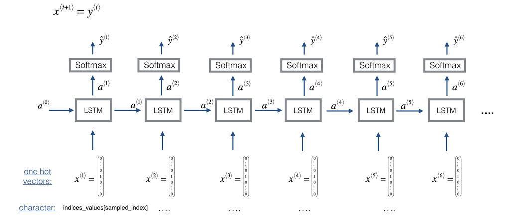

```python
Image("images/music_generation.png", height=900, width=900)
```

- We're going to train a model that predicts the next note in a style that is similar to the jazz music that it's trained on. The training is contained in the weights and biases of the model.
- Then we're going to use those weights and biases in a new model which predicts a series of notes, using the previous note to predict the next note.
- The weights and biases are transferred to the new model using 'global shared layers' described below"

## Building the model

- In this part you will build and train a model that will learn musical patterns.
- The model takes input X of shape $(m, T_x, 78)$ and labels Y of shape $(T_y, m, 78)$.
- We will use an LSTM with hidden states that have $n_{a} = 64$ dimensions.

```python
# number of dimensions for the hidden state of each LSTM cell.
n_a = 64
```

#### Sequence generation uses a for-loop

- If you're building an RNN where, at test time, the entire input sequence $x^{\langle 1 \rangle}, x^{\langle 2 \rangle}, \ldots, x^{\langle T_x \rangle}$ is given in advance, then Keras has simple built-in functions to build the model.
- However, for sequence generation, at test time we don't know all the values of $x^{\langle t\rangle}$ in advance.
- Instead we generate them one at a time using $x^{\langle t\rangle} = y^{\langle t-1 \rangle}$.
  - The input at time "t" is the prediction at the previous time step "t-1".
- So you'll need to implement your own for-loop to iterate over the time steps.

#### Shareable weights

- The function `djmodel()` will call the LSTM layer $T_x$ times using a for-loop.
- It is important that all $T_x$ copies have the same weights.
  - The $T_x$ steps should have shared weights that aren't re-initialized.
- Referencing a globally defined shared layer will utilize the same layer-object instance at each time step.
- The key steps for implementing layers with shareable weights in Keras are:
- Define the layer objects (we will use global variables for this).
- Call these objects when propagating the input.

#### 3 types of layers

Please read the Keras documentation and understand these layers:

- [Reshape](https://keras.io/layers/core/#reshape): Reshapes an output to a certain shape.
- [LSTM](https://keras.io/layers/recurrent/#lstm) : Long Short-Term Memory layer
- [Dense](https://keras.io/layers/core/#dense) : A regular fully-connected neural network layer.

```python
n_values = 78 # number of music values
reshapor = Reshape((1, n_values))                  # Used in Step 2.B of djmodel(), below
LSTM_cell = LSTM(n_a, return_state = True)         # Used in Step 2.C
densor = Dense(n_values, activation='softmax')     # Used in Step 2.D
```

- `reshapor`, `LSTM_cell` and `densor` are globally defined layer objects, that you'll use to implement `djmodel()`.
- In order to propagate a Keras tensor object X through one of these layers, use `layer_object()`.
  - For one input, use `layer_object(X)`
  - For more than one input, put the inputs in a list: `layer_object([X1,X2])`

**Exercise**: Implement `djmodel()`.

- The `Input()` layer is used for defining the input `X` as well as the initial hidden state `a0` and cell state `c0`.
- The `shape` parameter takes a tuple that does not include the batch dimension (`m`).
  - For example,

    ```
    X = Input(shape=(Tx, n_values)) # X has 3 dimensions and not 2: (m, Tx, n_values)
    ```

#### Step 1: Outputs

Create an empty list `outputs` to save the outputs of the LSTM Cell at every time step.

#### Step 2: Loop through time steps

- Loop for $t \in 1, \ldots, T_x$:

#### 2A. Select the `t` time-step vector from X.

- X has the shape (m, Tx, n_values).
- The shape of the 't' selection should be (n_values,).
- Recall that if you were implementing in numpy instead of Keras, you would extract a slice from a 3D numpy array like this:

  ```
  var1 = array1[:,1,:]
  ```

#### Lambda layer

- Since we're using Keras, we need to define this step inside a custom layer.
- In Keras, this is a Lambda layer [Lambda](https://keras.io/layers/core/#lambda)
- As an example, a Lambda layer that takes the previous layer and adds '1' looks like this

  ```
       lambda_layer1 = Lambda(lambda z: z + 1)(previous_layer)
  ```

- The previous layer in this case is `X`.
- `z` is a local variable of the lambda function.
  - The `previous_layer` gets passed into the parameter `z` in the lowercase `lambda` function.
  - You can choose the name of the variable to be something else if you want.
- The operation after the colon ':' should be the operation to extract a slice from the previous layer.

#### 2B. Reshape `x` to be `(1, n_val)`.

- Use the `reshapor()` layer. It is a function that takes the previous layer as its input argument.

#### 2C. Run `x` through one step of LSTM_cell.

- Initialize the `LSTM_cell` with the previous step's hidden state $a$ and cell state $c$.
- Use the following formatting:

  ```
  next_hidden_state, _, next_cell_state = LSTM_cell(inputs=input_x, initial_state=[previous_hidden_state, previous_cell_state])
  ```

- Choose appropriate variables for inputs, hidden state and cell state.

#### 2D. Dense layer

- Propagate the LSTM's hidden state through a dense+softmax layer using `densor`.

#### 2E. Append output

- Append the output to the list of `outputs`.

#### Step 3: After the loop, create the model

- Use the Keras `Model` object to create a model.
- specify the inputs and outputs:

  ```
  model = Model(inputs=[input_x, initial_hidden_state, initial_cell_state], outputs=the_outputs)
  ```

  - Choose the appropriate variables for the input tensor, hidden state, cell state, and output.
- See the documentation for [Model](https://keras.io/models/model/)

```python
def djmodel(Tx, n_a, n_values):
    """
    Implement the model

    Arguments:
    Tx  -- length of the sequence in a corpus
    n_a -- the number of activations used in our model
    n_values -- number of unique values in the music data

    Returns:
    model -- a keras instance model with n_a activations
    """

    # Define the input layer and specify the shape
    X = Input(shape=(Tx, n_values))

    # Define the initial hidden state a0 and initial cell state c0
    # using `Input`
    a0 = Input(shape=(n_a,), name='a0')
    c0 = Input(shape=(n_a,), name='c0')
    a = a0
    c = c0

    # Step 1: Create empty list to append the outputs while you iterate (≈1 line)
    outputs = []

    # Step 2: Loop
    for t in range(Tx):
        x = Lambda(lambda x:X[:,t,:])(X)             #2.A: select the "t"-th time step vector from X.
        x = x = reshapor(x)                          #2.B: Use reshapor to reshape x to be (1, n_values)
        a, _, c = LSTM_cell(x, initial_state=[a, c]) #2.C: Perform one step of the LSTM_cell
        out = densor(a)                              #2.D: Apply densor to the hidden state output of LSTM_Cell
        outputs.append(out)                          #2.E: add the output to "outputs"

    # Step 3: Create model instance
    model = Model([X, a0, c0], outputs)
    return model
```

```python
model = djmodel(Tx = 30 , n_a = 64, n_values = 78)
```

```python
# Check your model
model.summary()
```

```
____________________________________________________________________________________________________
Layer (type)                     Output Shape          Param #     Connected to
====================================================================================================
input_1 (InputLayer)             (None, 30, 78)        0
____________________________________________________________________________________________________
lambda_1 (Lambda)                (None, 78)            0           input_1[0][0]
____________________________________________________________________________________________________
reshape_1 (Reshape)              (None, 1, 78)         0           lambda_1[0][0]
                                                                   lambda_2[0][0]
                                                                   lambda_3[0][0]
                                                                   lambda_4[0][0]
                                                                   lambda_5[0][0]
                                                                   lambda_6[0][0]
                                                                   lambda_7[0][0]
                                                                   lambda_8[0][0]
                                                                   lambda_9[0][0]
                                                                   lambda_10[0][0]
                                                                   lambda_11[0][0]
                                                                   lambda_12[0][0]
                                                                   lambda_13[0][0]
                                                                   lambda_14[0][0]
                                                                   lambda_15[0][0]
                                                                   lambda_16[0][0]
                                                                   lambda_17[0][0]
                                                                   lambda_18[0][0]
                                                                   lambda_19[0][0]
                                                                   lambda_20[0][0]
                                                                   lambda_21[0][0]
                                                                   lambda_22[0][0]
                                                                   lambda_23[0][0]
                                                                   lambda_24[0][0]
                                                                   lambda_25[0][0]
                                                                   lambda_26[0][0]
                                                                   lambda_27[0][0]
                                                                   lambda_28[0][0]
                                                                   lambda_29[0][0]
                                                                   lambda_30[0][0]
____________________________________________________________________________________________________
a0 (InputLayer)                  (None, 64)            0
____________________________________________________________________________________________________
```

[output cut: 171 more lines]

```
                                                                   lstm_1[20][0]
                                                                   lstm_1[21][0]
                                                                   lstm_1[22][0]
                                                                   lstm_1[23][0]
                                                                   lstm_1[24][0]
                                                                   lstm_1[25][0]
                                                                   lstm_1[26][0]
                                                                   lstm_1[27][0]
                                                                   lstm_1[28][0]
                                                                   lstm_1[29][0]
====================================================================================================
Total params: 41,678
Trainable params: 41,678
Non-trainable params: 0
____________________________________________________________________________________________________
```

#### Compile the model for training

- Use:
  - optimizer: `Adam`
  - Loss function: `categorical_crossentropy` (for multi-class classification)

```python
opt = Adam(lr=0.01, beta_1=0.9, beta_2=0.999, decay=0.01)
model.compile(optimizer=opt, loss='categorical_crossentropy', metrics=['accuracy'])
```

#### Initialize hidden state and cell state

Finally, let's initialize `a0` and `c0` for the LSTM's initial state to be zero.

```python
m = 60
a0 = np.zeros((m, n_a))
c0 = np.zeros((m, n_a))
```

#### Train the model

- Lets now fit the model!
- We will turn `Y` into a list, since the cost function expects `Y` to be provided in this format
  - `list(Y)` is a list with 30 items, where each of the list items is of shape (60,78).
  - Lets train for 100 epochs.

```python
model.fit([X, a0, c0], list(Y), epochs=100, verbose=False)
```

```
<keras.callbacks.History at 0x7fe5a7c66e10>
```

## Generating music

#### Predicting and Sampling

At each step of sampling, you will:

- Take as input the activation '`a`' and cell state '`c`' from the previous state of the LSTM.
- Forward propagate by one step.
- Get a new output activation as well as cell state.
- The new activation '`a`' can then be used to generate the output using the fully connected layer, `densor`.

##### Initialization

- We will initialize the following to be zeros:
  - `x0`
  - hidden state `a0`
  - cell state `c0`

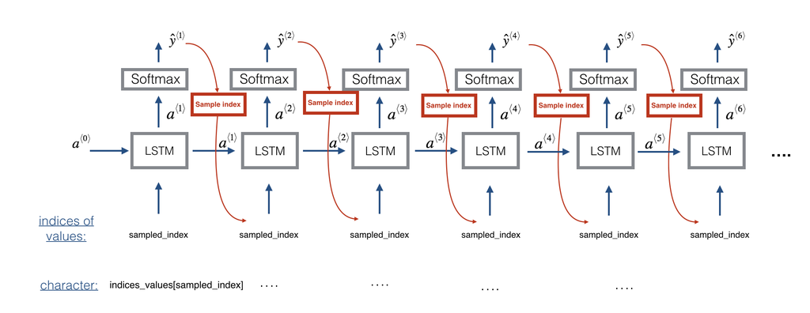

```python
Image("images/music_gen.png", height=600)
```

**Exercise:**

- Here are some of the key steps you'll need to implement inside the for-loop that generates the $T_y$ output characters:
- Step 2A: Use `LSTM_Cell`, which takes in the input layer, as well as the previous step's `c` and `a` to generate the current step's `c` and `a`.

```
next_hidden_state, _, next_cell_state = LSTM_cell(input_x, initial_state=[previous_hidden_state, previous_cell_state])
```

- Step 2B:

  Compute the output by applying `densor` to compute a softmax on '`a`' to get the output for the current step.
- Step 2C:

  Append the output to the list `outputs`.
- Step 2D

  Sample x to be the one-hot version of `out`.
  - This allows you to pass it to the next LSTM's step.
  - We have provided the definition of `one_hot(x)` in the `music_utils.py` file and imported it. Here is the definition of `one_hot`

    ```
    def one_hot(x):
      x = K.argmax(x)
      x = tf.one_hot(indices=x, depth=78)
      x = RepeatVector(1)(x)
      return x
    ```

- `argmax`: within the vector `x`, find the position with the maximum value and return the index of that position.
  - For example: argmax of [-1,0,1] finds that 1 is the maximum value, and returns the index position.
- `one_hot`: takes a list of indices and the depth of the one-hot vector (number of categories, which is 78 in this assignment). It converts each index into the one-hot vector representation. For instance, if the indices is [2], and the depth is 5, then the one-hot vector returned is [0,0,1,0,0].
- `RepeatVector(n)`: This takes a vector and duplicates it `n` times. Notice that we had it repeat 1 time. This may seem like it's not doing anything. You'll notice that if x is a vector with dimension (m,5) and it gets passed into `RepeatVector(1)`, then the output is (m,1,5). In other words, it adds an additional dimension (of length 1) to the resulting vector.
- Apply the custom `one_hot encoding` using the `Lambda`layer.

  ```
  result = Lambda(lambda x: x + 1)(input_var)
  ```

If you pre-define a function, you can do the same thing:

```
def add_one(x)
    return x + 1

# use the add_one function inside of the Lambda function
result = Lambda(add_one)(input_var)
```

Step 3 Inference Model

This is how to use the Keras `Model`.

```
model = Model(inputs=[input_x, initial_hidden_state, initial_cell_state], outputs=the_outputs)
```

- **Hint**: the inputs to the model are the **initial** inputs and states.

```python
# music_inference_model

def music_inference_model(LSTM_cell, densor, n_values = 78, n_a = 64, Ty = 100):
    """
    Uses the trained "LSTM_cell" and "densor" from model() to generate a sequence of values.

    Arguments:
    LSTM_cell -- the trained "LSTM_cell" from model(), Keras layer object
    densor -- the trained "densor" from model(), Keras layer object
    n_values -- integer, number of unique values
    n_a -- number of units in the LSTM_cell
    Ty -- integer, number of time steps to generate

    Returns:
    inference_model -- Keras model instance
    """

    # Define the input of your model with a shape
    x0 = Input(shape=(1, n_values))

    # Define s0, initial hidden state for the decoder LSTM
    a0 = Input(shape=(n_a,), name='a0')
    c0 = Input(shape=(n_a,), name='c0')
    a = a0
    c = c0
    x = x0

    # Step 1: Create an empty list of "outputs"
    outputs = []

    # Step 2: Loop over Ty and generate a value at every time step
    for t in range(Ty):

        a, _, c = LSTM_cell(x,initial_state=[a,c])  #2A: Perform one step of LSTM_cell
        out = densor(a)                             #2B: Apply Dense layer to the hidden state output
        outputs.append(out)                         #2C: Append the prediction "out" to "outputs".
                                                    #    out.shape = (None, 78)

        # Step 2.D:
        # Select the next value according to "out",
        # Set "x" to be the one-hot representation of the selected value
        # See instructions above.
        x = Lambda(one_hot)(out)

    # Step 3: Create model instance with the correct "inputs" and "outputs"
    inference_model =Model([x0, a0, c0], outputs)
    return inference_model
```

```python
inference_model = music_inference_model(LSTM_cell, densor, n_values = 78, n_a = 64, Ty = 50)
```

```python
# Check the inference model
inference_model.summary()
```

```
____________________________________________________________________________________________________
Layer (type)                     Output Shape          Param #     Connected to
====================================================================================================
input_2 (InputLayer)             (None, 1, 78)         0
____________________________________________________________________________________________________
a0 (InputLayer)                  (None, 64)            0
____________________________________________________________________________________________________
c0 (InputLayer)                  (None, 64)            0
____________________________________________________________________________________________________
lstm_1 (LSTM)                    [(None, 64), (None, 6 36608       input_2[0][0]
                                                                   a0[0][0]
                                                                   c0[0][0]
                                                                   lambda_31[0][0]
                                                                   lstm_1[30][0]
                                                                   lstm_1[30][2]
                                                                   lambda_32[0][0]
                                                                   lstm_1[31][0]
                                                                   lstm_1[31][2]
                                                                   lambda_33[0][0]
                                                                   lstm_1[32][0]
                                                                   lstm_1[32][2]
                                                                   lambda_34[0][0]
                                                                   lstm_1[33][0]
                                                                   lstm_1[33][2]
                                                                   lambda_35[0][0]
                                                                   lstm_1[34][0]
                                                                   lstm_1[34][2]
                                                                   lambda_36[0][0]
                                                                   lstm_1[35][0]
                                                                   lstm_1[35][2]
                                                                   lambda_37[0][0]
                                                                   lstm_1[36][0]
                                                                   lstm_1[36][2]
                                                                   lambda_38[0][0]
                                                                   lstm_1[37][0]
                                                                   lstm_1[37][2]
                                                                   lambda_39[0][0]
                                                                   lstm_1[38][0]
                                                                   lstm_1[38][2]
                                                                   lambda_40[0][0]
```

[output cut: 258 more lines]

```
____________________________________________________________________________________________________
lambda_75 (Lambda)               (None, 1, 78)         0           dense_1[74][0]
____________________________________________________________________________________________________
lambda_76 (Lambda)               (None, 1, 78)         0           dense_1[75][0]
____________________________________________________________________________________________________
lambda_77 (Lambda)               (None, 1, 78)         0           dense_1[76][0]
____________________________________________________________________________________________________
lambda_78 (Lambda)               (None, 1, 78)         0           dense_1[77][0]
____________________________________________________________________________________________________
lambda_79 (Lambda)               (None, 1, 78)         0           dense_1[78][0]
====================================================================================================
Total params: 41,678
Trainable params: 41,678
Non-trainable params: 0
____________________________________________________________________________________________________
```

#### Initialize inference model

The following code creates the zero-valued vectors you will use to initialize `x` and the LSTM state variables `a` and `c`.

```python
x_initializer = np.zeros((1, 1, 78))
a_initializer = np.zeros((1, n_a))
c_initializer = np.zeros((1, n_a))
```

**Exercise**: Implement `predict_and_sample()`.

- This function takes many arguments including the inputs`[x_initializer, a_initializer, c_initializer]`.
- In order to predict the output corresponding to this input, you will need to carry-out 3 steps:

#### Step 1

- Use your inference model to predict an output given your set of inputs. The output `pred` should be a list of length $T_y$ where each element is a numpy-array of shape (1, n_values).

```
inference_model.predict([input_x_init, hidden_state_init, cell_state_init])
```

#### Step 2

- Convert `pred` into a numpy array of $T_y$ indices.
  - Each index is computed by taking the `argmax` of an element of the `pred` list.
  - Set the `axis` parameter.
    - Remember that the shape of the prediction is $(m, T_{y}, n_{values})$

#### Step 3

- Convert the indices into their one-hot vector representations.
  - Use `to_categorical` function
  - Set the `num_classes` parameter.

```python
# predict_and_sample

def predict_and_sample(inference_model, x_initializer = x_initializer, a_initializer = a_initializer,
                       c_initializer = c_initializer):
    """
    Predicts the next value of values using the inference model.

    Arguments:
    inference_model -- Keras model instance for inference time
    x_initializer -- numpy array of shape (1, 1, 78), one-hot vector initializing the values generation
    a_initializer -- numpy array of shape (1, n_a), initializing the hidden state of the LSTM_cell
    c_initializer -- numpy array of shape (1, n_a), initializing the cell state of the LSTM_cel

    Returns:
    results -- numpy-array of shape (Ty, 78), matrix of one-hot vectors representing the values generated
    indices -- numpy-array of shape (Ty, 1), matrix of indices representing the values generated
    """


    # Step 1: Use inference model to predict output sequence given x_initializer, a_initializer, c_initializer.
    pred = inference_model.predict([x_initializer, a_initializer, c_initializer])

    # Step 2: Convert "pred" into an np.array() of indices with the maximum probabilities
    indices = np.argmax(pred,axis=2)

    # Step 3: Convert indices to one-hot vectors, the shape of the results should be (Ty, n_values)
    results = to_categorical(indices)

    return results, indices
```

```python
results, indices = predict_and_sample(inference_model, x_initializer, a_initializer, c_initializer)
print("np.argmax(results[12]) =", np.argmax(results[12]))
print("np.argmax(results[17]) =", np.argmax(results[17]))
print("list(indices[12:18])   =", list(indices[12:18]))
```

```
np.argmax(results[12]) = 44
np.argmax(results[17]) = 25
list(indices[12:18])   = [array([44]), array([57]), array([44]), array([71]), array([21]), array([25])]
```

## Generate music

Finally, you are ready to generate music. Your RNN generates a sequence of values. The following code generates music by first calling your `predict_and_sample()` function. These values are then post-processed into musical chords (meaning that multiple values or notes can be played at the same time).

Most computational music algorithms use some post-processing because it is difficult to generate music that sounds good without such post-processing. The post-processing does things such as clean up the generated audio by making sure the same sound is not repeated too many times, that two successive notes are not too far from each other in pitch, and so on. One could argue that a lot of these post-processing steps are hacks; also, a lot of the music generation literature has also focused on hand-crafting post-processors, and a lot of the output quality depends on the quality of the post-processing and not just the quality of the RNN. But this post-processing does make a huge difference, so let's use it in our implementation as well.

```python
out_stream = generate_music(inference_model)
```

```
Predicting new values for different set of chords.
Generated 51 sounds using the predicted values for the set of chords ("1") and after pruning
Generated 51 sounds using the predicted values for the set of chords ("2") and after pruning
Generated 51 sounds using the predicted values for the set of chords ("3") and after pruning
Generated 51 sounds using the predicted values for the set of chords ("4") and after pruning
Generated 51 sounds using the predicted values for the set of chords ("5") and after pruning
Your generated music is saved in output/my_music.midi
```

```python
IPython.display.Audio('./data/30s_trained_model.mp3')
```

[interactive chart not shown]